# Difference-in-Differences

## Line plots

The main identification assumption in the DinD framework is *common trends*. One way to see whether the assumption is reasonable in your setting is through line plots. The first step is to show how the outcomes in both treatment and control groups evolve - preferable with multiple pre-intervention periods.

Let’s replicate Figure 5.2 from Angrist and Pischke (2014) and see how trends in bank failures in Mississippi evolved before, during, and after the Caldwell crisis. Download the data [here](https://github.com/guerramarcelino/PolicyEval/raw/main/Datasets/banks.RDS). In this exercise, we use the packages `ggplot2` and `ggthemes`.

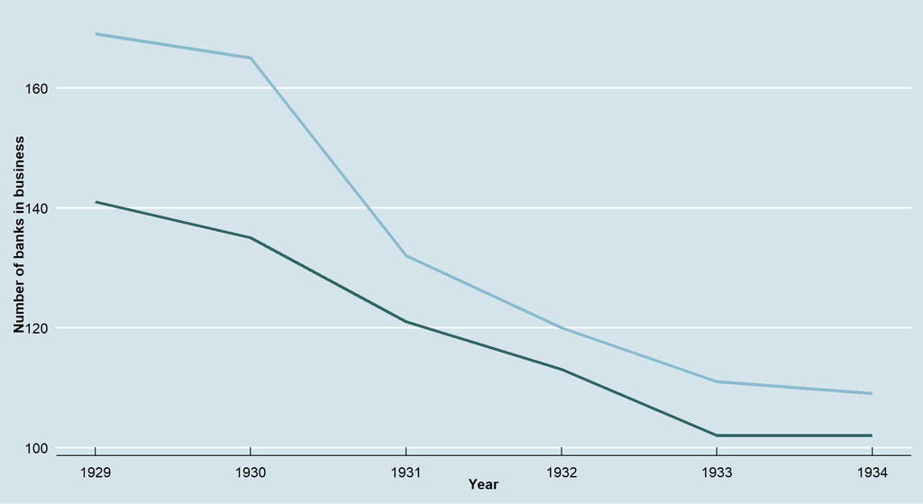

```r
# If you don't have the packages, start with install.packages("ggplot2") and
# install.packages("ggthemes")
library(ggplot2)
library(ggthemes)

banks<-readRDS("banks.RDS")

plot1<-ggplot()+
  geom_line(data=banks, aes(x=year, y=`6th district`),size=1.4, color="#336666")+
  geom_line(data=banks, aes(x=year, y=`8th district`),size=1.4, color="#8abbd0")+
  labs(x = "Year", y="Number of banks in business")+
  theme_economist(base_size = 14) +
  scale_colour_economist()+
   theme(axis.text=element_text(size=12),
        axis.title=element_text(size=12,face="bold"))

plot1
```

Instead of using `geom_line()` for each district, you can reshape the dataset. That will easily allow you to have legends for each line:

```r
library(reshape2)
panel_banks<-melt(banks, id.var='year')
head(panel_banks,5)
```

```
##   year     variable value
## 1 1929 6th district   141
## 2 1930 6th district   135
## 3 1931 6th district   121
## 4 1932 6th district   113
## 5 1933 6th district   102
```

Then, you apply almost the same code and get the plot with legends:

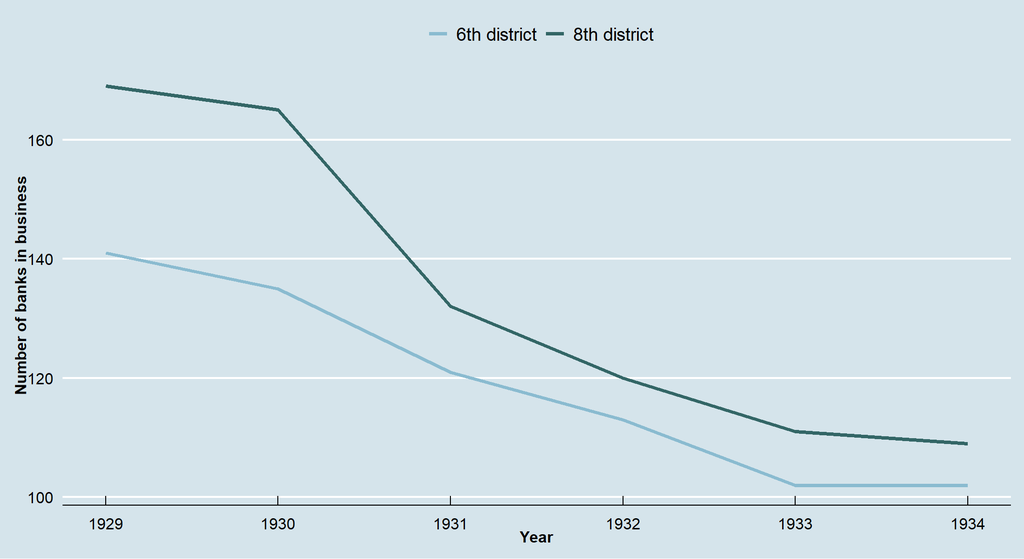

```r
plot2<-ggplot()+
  geom_line(data=panel_banks, aes(x=year, y=value, col=variable),size=1.4)+
  scale_color_manual("", values=c("#8abbd0", "#336666"))+
  labs(x = "Year", y="Number of banks in business")+
  theme_economist(base_size = 14) +
  theme(axis.text=element_text(size=12),
      axis.title=element_text(size=12,face="bold"))
plot2
```

`ggplot2` allows you to customize your graphs in many ways. For example, if you want different line types:

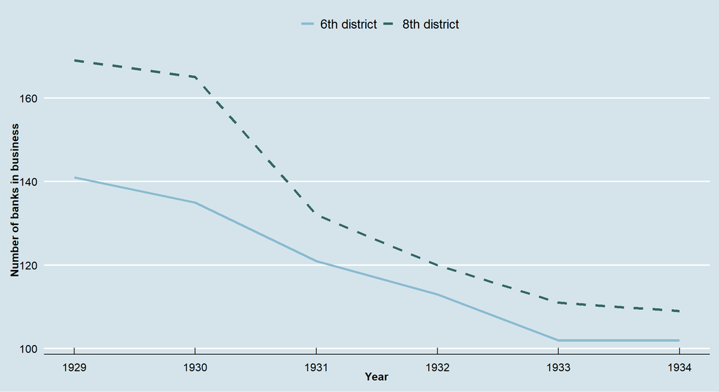

```r
plot3<-ggplot()+
  geom_line(data=panel_banks, aes(x=year, y=value, col=variable, linetype = variable),size=1.4)+
  scale_color_manual("", values=c("#8abbd0", "#336666"))+
  scale_linetype_manual("", values = c("solid", "dashed"))+
  labs(x = "Year", y="Number of banks in business")+
  theme_economist(base_size = 14) +
  theme(axis.text=element_text(size=12),
      axis.title=element_text(size=12,face="bold"))
plot3
```

Check also `ggthemes` [here](https://yutannihilation.github.io/allYourFigureAreBelongToUs/ggthemes/). There you have plenty of options for the plot background.

## Difference-in-Differences Example: Cheng and Hoekstra (2013)

These notes are mostly based on [Cunningham (2021)](https://mixtape.scunning.com/difference-in-differences.html?panelset6=r-code7&panelset4=r-code5&panelset7=r-code8&panelset5=r-code6#replicating-cheng2013-sort-of). This exercise replicates some of the results of [Cheng and Hoekstra (2013)](http://jhr.uwpress.org/content/48/3/821.short). The dataset ([download here](https://github.com/guerramarcelino/PolicyEval/raw/main/Datasets/castle.RDS)) comprehends 50 U.S states during the period 2000-2010. The authors aimed to evaluate the effect of the staggered adoption of “stand your ground” laws on crime. Check lecture notes for discussion here.

The variables are described below:

Variables Description

| Variable | Definition |
| --- | --- |
| state | U.S. State |
| year | Year |
| region | Census Region. 1 if northeast, 2 if midwest, 3 if south and 4 if west |
| treated | 1 if state is treated at any point from 2000 and 2010 |
| cdl | Treatment variable. Takes values from 0 to 1, depending on which month of the year the new law was passed |
| l_motor | Motor theft rate (in log) |
| l_larceny | Larceny rate (in log) |
| l_robbery | Robbery rate (in log) |
| l_assault | Aggravated Assault rate (in log) |
| l_homicide | Murder rate (in log) |
| blackm_15_24 | % of black male aged 15-24 |
| whitem_15_24 | % of white male aged 15-24 |
| blackm_25_44 | % of black male aged 25-44 |
| whitem_25_44 | % of white male aged 25-44 |
| l_exp_subsidy | Government spending (assistance and subsidies) per capita (in log) |
| l_exp_pubwelfare | Government spending (public welfare) per capita (in log) |
| l_police | Police per 100,000 residents (in log) |
| unemployrt | Unemployment Rate (%) |
| poverty | Poverty Rate (%) |
| l_income | Median Household Income ($) (in log) |
| l_prisoner | Prisoners per 100,000 residents (in log) |
| l_lagprisoner | Lag prisoners per 100,000 residents (in log) |
| popwt | State Population (used in the weighted regression) |

### Falsification tests

```r
castle<-readRDS("castle.RDS")
library(fixest)
library(tidyverse)
## TWFE
reg_motor1<-feols(l_motor~cdl|state+year, cluster=~state, data=castle)

## TWFE with Region-by-Year Fixed Effects
reg_motor2<-feols(l_motor~cdl|state+year+region^year, cluster=~state, data=castle)

## TWFE with Region-by-Year Fixed Effects, additional controls and State-Specific Linear Time trends
reg_motor3<-feols(l_motor~cdl+blackm_15_24+whitem_15_24+blackm_25_44+
              whitem_25_44+l_exp_subsidy+l_exp_pubwelfare+l_police+
              unemployrt+poverty+l_income+l_prisoner+l_lagprisoner+
              state:year
              |state+year+region^year, cluster=~state, data=castle)

etable(reg_motor1,reg_motor2,reg_motor3,signifCode = c("***"=0.01, "**"=0.05, "*"=0.10),   keep=c("cdl","blackm_15_24","whitem_15_24","blackm_25_44",
                     "whitem_25_44","l_exp_subsidy","l_exp_pubwelfare","l_police",
                     "unemployrt","poverty","l_income","l_prisoner","l_lagprisoner"))
```

```
##                        reg_motor1      reg_motor2         reg_motor3
## Dependent Var.:           l_motor         l_motor            l_motor
##
## cdl              0.0766* (0.0413) 0.0138 (0.0450)   -0.0037 (0.0367)
## blackm_15_24                                       -0.0952* (0.0487)
## whitem_15_24                                         0.0046 (0.0155)
## blackm_25_44                                       0.0593** (0.0285)
## whitem_25_44                                        -0.0031 (0.0069)
## l_exp_subsidy                                       -0.0144 (0.0309)
## l_exp_pubwelfare                                    -0.0527 (0.0703)
## l_police                                             0.0049 (0.0372)
## unemployrt                                        -0.0340** (0.0152)
## poverty                                             -0.0010 (0.0114)
## l_income                                            -0.1193 (0.1288)
## l_prisoner                                          -0.0066 (0.1831)
## l_lagprisoner                                       -0.2187 (0.2102)
## Fixed-Effects:   ---------------- --------------- ------------------
## state                         Yes             Yes                Yes
## year                          Yes             Yes                Yes
## region^year                    No             Yes                Yes
## ________________ ________________ _______________ __________________
## S.E.: Clustered         by: state       by: state          by: state
## Observations                  550             550                550
## R2                        0.95815         0.96851            0.98604
## Within R2                 0.02611         0.00085            0.55696
```

```r
reg_lar1<-feols(l_larceny~cdl|state+year, cluster=~state, data=castle)
reg_lar2<-feols(l_larceny~cdl|state+year+region^year, cluster=~state, data=castle)
reg_lar3<-feols(l_larceny~cdl+blackm_15_24+whitem_15_24+blackm_25_44+
              whitem_25_44+l_exp_subsidy+l_exp_pubwelfare+l_police+
              unemployrt+poverty+l_income+l_prisoner+l_lagprisoner+
              state:year
            |state+year+region^year, cluster=~state, data=castle)

etable(reg_lar1,reg_lar2,reg_lar3,signifCode = c("***"=0.01, "**"=0.05, "*"=0.10),   keep=c("cdl","blackm_15_24","whitem_15_24","blackm_25_44",
                     "whitem_25_44","l_exp_subsidy","l_exp_pubwelfare","l_police",
                     "unemployrt","poverty","l_income","l_prisoner","l_lagprisoner"))
```

```
##                         reg_lar1        reg_lar2          reg_lar3
## Dependent Var.:        l_larceny       l_larceny         l_larceny
##
## cdl              0.0075 (0.0227) 0.0015 (0.0208)  -0.0137 (0.0231)
## blackm_15_24                                      -0.0489 (0.0368)
## whitem_15_24                                      -0.0022 (0.0105)
## blackm_25_44                                     0.0492** (0.0230)
## whitem_25_44                                       0.0018 (0.0043)
## l_exp_subsidy                                     -0.0056 (0.0144)
## l_exp_pubwelfare                                   0.0485 (0.0318)
## l_police                                          -0.0203 (0.0179)
## unemployrt                                        -0.0010 (0.0061)
## poverty                                            0.0033 (0.0073)
## l_income                                           0.0076 (0.0738)
## l_prisoner                                        -0.1146 (0.0780)
## l_lagprisoner                                      0.0311 (0.0987)
## Fixed-Effects:   --------------- --------------- -----------------
## state                        Yes             Yes               Yes
## year                         Yes             Yes               Yes
## region^year                   No             Yes               Yes
## ________________ _______________ _______________ _________________
## S.E.: Clustered        by: state       by: state         by: state
## Observations                 550             550               550
## R2                       0.94217         0.96118           0.98078
## Within R2                0.00096         3.97e-5           0.50489
```

### Deterrence

```r
reg_rob1<-feols(l_robbery~cdl|state+year, cluster=~state, data=castle)
reg_rob2<-feols(l_robbery~cdl|state+year+region^year, cluster=~state, data=castle)
reg_rob3<-feols(l_robbery~cdl+blackm_15_24+whitem_15_24+blackm_25_44+
              whitem_25_44+l_exp_subsidy+l_exp_pubwelfare+l_police+
              unemployrt+poverty+l_income+l_prisoner+l_lagprisoner+
              state:year
            |state+year+region^year, cluster=~state, data=castle)

etable(reg_rob1,reg_rob2,reg_rob3,signifCode = c("***"=0.01, "**"=0.05, "*"=0.10),   keep=c("cdl","blackm_15_24","whitem_15_24","blackm_25_44",
                     "whitem_25_44","l_exp_subsidy","l_exp_pubwelfare","l_police",
                     "unemployrt","poverty","l_income","l_prisoner","l_lagprisoner"))
```

```
##                         reg_rob1        reg_rob2           reg_rob3
## Dependent Var.:        l_robbery       l_robbery          l_robbery
##
## cdl              0.0448 (0.0331) 0.0320 (0.0426)    0.0267 (0.0303)
## blackm_15_24                                     -0.2014** (0.0845)
## whitem_15_24                                        0.0103 (0.0230)
## blackm_25_44                                      0.1625** (0.0735)
## whitem_25_44                                       -0.0121 (0.0109)
## l_exp_subsidy                                       0.0061 (0.0261)
## l_exp_pubwelfare                                   -0.0798 (0.0718)
## l_police                                            0.0132 (0.0305)
## unemployrt                                         -0.0101 (0.0103)
## poverty                                            -0.0095 (0.0116)
## l_income                                            0.0391 (0.1221)
## l_prisoner                                          0.0453 (0.1845)
## l_lagprisoner                                     -0.3073* (0.1576)
## Fixed-Effects:   --------------- --------------- ------------------
## state                        Yes             Yes                Yes
## year                         Yes             Yes                Yes
## region^year                   No             Yes                Yes
## ________________ _______________ _______________ __________________
## S.E.: Clustered        by: state       by: state          by: state
## Observations                 550             550                550
## R2                       0.98516         0.98620            0.99273
## Within R2                0.01156         0.00467            0.47609
```

```r
reg_aslt1<-feols(l_assault~cdl|state+year, cluster=~state, data=castle)
reg_aslt2<-feols(l_assault~cdl|state+year+region^year, cluster=~state, data=castle)
reg_aslt3<-feols(l_assault~cdl+blackm_15_24+whitem_15_24+blackm_25_44+
                  whitem_25_44+l_exp_subsidy+l_exp_pubwelfare+l_police+
                  unemployrt+poverty+l_income+l_prisoner+l_lagprisoner+
                  state:year
                |state+year+region^year, cluster=~state, data=castle)

etable(reg_aslt1,reg_aslt2,reg_aslt3,signifCode = c("***"=0.01, "**"=0.05, "*"=0.10),   keep=c("cdl","blackm_15_24","whitem_15_24","blackm_25_44",
                     "whitem_25_44","l_exp_subsidy","l_exp_pubwelfare","l_police",
                     "unemployrt","poverty","l_income","l_prisoner","l_lagprisoner"))
```

```
##                        reg_aslt1       reg_aslt2          reg_aslt3
## Dependent Var.:        l_assault       l_assault          l_assault
##
## cdl              0.0555 (0.0604) 0.0698 (0.0638)    0.0317 (0.0386)
## blackm_15_24                                        0.0895 (0.0681)
## whitem_15_24                                       -0.0456 (0.0346)
## blackm_25_44                                       -0.0567 (0.0343)
## whitem_25_44                                        0.0103 (0.0115)
## l_exp_subsidy                                      -0.0096 (0.0260)
## l_exp_pubwelfare                                    0.0603 (0.0404)
## l_police                                         0.1029*** (0.0232)
## unemployrt                                          0.0097 (0.0083)
## poverty                                            -0.0068 (0.0099)
## l_income                                            0.0120 (0.1117)
## l_prisoner                                         -0.0065 (0.1441)
## l_lagprisoner                                      -0.0126 (0.1377)
## Fixed-Effects:   --------------- --------------- ------------------
## state                        Yes             Yes                Yes
## year                         Yes             Yes                Yes
## region^year                   No             Yes                Yes
## ________________ _______________ _______________ __________________
## S.E.: Clustered        by: state       by: state          by: state
## Observations                 550             550                550
## R2                       0.94615         0.95273            0.98960
## Within R2                0.01076         0.01415            0.78305
```

### Homicide in Florida

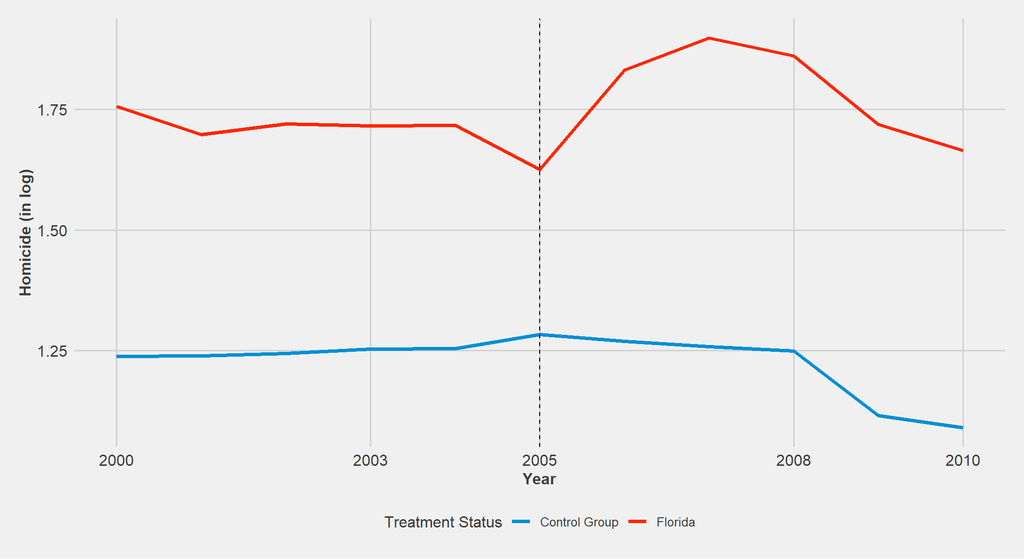

```r
florida<-castle%>%filter(state=="Florida"|treated==0)
florida<-florida%>%mutate(treat=ifelse(state=="Florida","Florida","Control Group"))
plot<-florida%>%group_by(treat, year)%>%summarize(Homicide=mean(l_homicide))

library(ggthemes)
  ggplot()+
  geom_line(data=plot,
            aes(x=year, y=Homicide, col=treat),
            size=1.4)+
  scale_color_fivethirtyeight("Treatment Status")+
  theme_fivethirtyeight()+
  labs(x = "Year", y="Homicide (in log)")+
  geom_vline(xintercept = 2005, linetype="dashed")+
  scale_x_continuous(breaks=c(2000, 2003, 2005, 2008, 2010))+
  theme(axis.text=element_text(size=12),
        axis.title=element_text(size=12,face="bold"))
```

```r
reg_homic1_fl<-feols(l_homicide~cdl|state+year, cluster=~state, data=florida)
reg_homic2_fl<-feols(l_homicide~cdl|state+year+region^year, cluster=~state, data=florida)
reg_homic3_fl<-feols(l_homicide~cdl+blackm_15_24+whitem_15_24+blackm_25_44+
                  whitem_25_44+l_exp_subsidy+l_exp_pubwelfare+l_police+
                  unemployrt+poverty+l_income+l_prisoner+l_lagprisoner+
                  state:year
                |state+year+region^year, cluster=~state, data=florida)

etable(reg_homic1_fl,reg_homic2_fl,reg_homic3_fl,signifCode = c("***"=0.01, "**"=0.05, "*"=0.10),   keep=c("cdl","blackm_15_24","whitem_15_24","blackm_25_44",
                     "whitem_25_44","l_exp_subsidy","l_exp_pubwelfare","l_police",
                     "unemployrt","poverty","l_income","l_prisoner","l_lagprisoner"))
```

```
##                       reg_homic1_fl   reg_homic2_fl       reg_homic3_fl
## Dependent Var.:          l_homicide      l_homicide          l_homicide
##
## cdl              0.1376*** (0.0353) 0.0457 (0.1134)   0.2674** (0.1192)
## blackm_15_24                                           -0.0366 (0.1948)
## whitem_15_24                                            0.1264 (0.0793)
## blackm_25_44                                            0.0710 (0.1585)
## whitem_25_44                                        -0.0496*** (0.0164)
## l_exp_subsidy                                           0.0530 (0.0607)
## l_exp_pubwelfare                                      0.4054** (0.1766)
## l_police                                                0.2374 (0.3583)
## unemployrt                                            0.0489** (0.0227)
## poverty                                              -0.0706** (0.0334)
## l_income                                              -0.6636* (0.3297)
## l_prisoner                                           -1.034*** (0.3533)
## l_lagprisoner                                           0.1821 (0.3755)
## Fixed-Effects:   ------------------ --------------- -------------------
## state                           Yes             Yes                 Yes
## year                            Yes             Yes                 Yes
## region^year                      No             Yes                 Yes
## ________________ __________________ _______________ ___________________
## S.E.: Clustered           by: state       by: state           by: state
## Observations                    330             330                 330
## R2                          0.91563         0.92657             0.95739
## Within R2                   0.00515         0.00057             0.42002
```

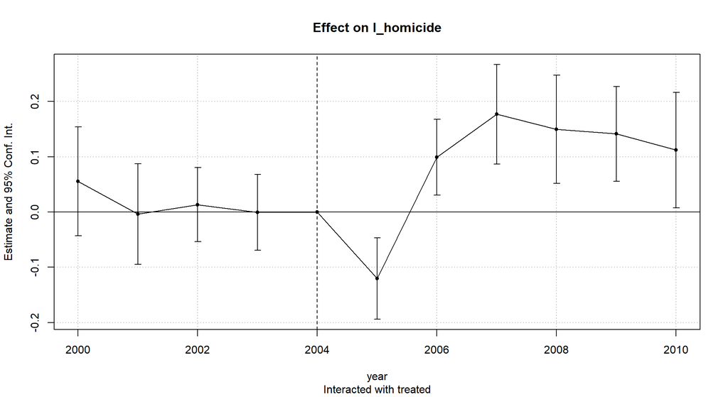

```r
florida_plot = feols(l_homicide~i(treated, year, 2004)|state+year, cluster=~state, data=florida)
coefplot(florida_plot)
```

### Multistate Homicide Regression

```r
reg_homic1<-feols(l_homicide~cdl|state+year, cluster=~state, data=castle)
reg_homic2<-feols(l_homicide~cdl|state+year+region^year, cluster=~state, data=castle)
reg_homic3<-feols(l_homicide~cdl+blackm_15_24+whitem_15_24+blackm_25_44+
                     whitem_25_44+l_exp_subsidy+l_exp_pubwelfare+l_police+
                     unemployrt+poverty+l_income+l_prisoner+l_lagprisoner+
                     state:year
                   |state+year+region^year,cluster=~state, data=castle)

etable(reg_homic1,reg_homic2,reg_homic3,signifCode = c("***"=0.01, "**"=0.05, "*"=0.10),
       keep=c("cdl","blackm_15_24","whitem_15_24","blackm_25_44",
                     "whitem_25_44","l_exp_subsidy","l_exp_pubwelfare","l_police",
                     "unemployrt","poverty","l_income","l_prisoner","l_lagprisoner"))
```

```
##                       reg_homic1      reg_homic2          reg_homic3
## Dependent Var.:       l_homicide      l_homicide          l_homicide
##
## cdl              0.0877 (0.0638) 0.0811 (0.0779)     0.0672 (0.0457)
## blackm_15_24                                         0.0984 (0.1269)
## whitem_15_24                                        0.0676* (0.0401)
## blackm_25_44                                         0.1195 (0.1358)
## whitem_25_44                                     -0.0375*** (0.0133)
## l_exp_subsidy                                       -0.0686 (0.0595)
## l_exp_pubwelfare                                     0.0645 (0.1059)
## l_police                                           0.1465** (0.0643)
## unemployrt                                           0.0196 (0.0189)
## poverty                                           -0.0488** (0.0222)
## l_income                                          -0.5859** (0.2803)
## l_prisoner                                          -0.1407 (0.3372)
## l_lagprisoner                                       -0.2033 (0.3975)
## Fixed-Effects:   --------------- --------------- -------------------
## state                        Yes             Yes                 Yes
## year                         Yes             Yes                 Yes
## region^year                   No             Yes                 Yes
## ________________ _______________ _______________ ___________________
## S.E.: Clustered        by: state       by: state           by: state
## Observations                 550             550                 550
## R2                       0.91055         0.91527             0.95323
## Within R2                0.01308         0.00869             0.45273
```

```r
reg_homic1<-feols(l_homicide~cdl|state+year, cluster=~state,weights=castle$popwt, data=castle)
reg_homic2<-feols(l_homicide~cdl|state+year+region^year, weights=castle$popwt, cluster=~state, data=castle)
reg_homic3<-feols(l_homicide~cdl+blackm_15_24+whitem_15_24+blackm_25_44+
                     whitem_25_44+l_exp_subsidy+l_exp_pubwelfare+l_police+
                     unemployrt+poverty+l_income+l_prisoner+l_lagprisoner+
                     state:year
                   |state+year+region^year, weights=castle$popwt, cluster=~state, data=castle)

etable(reg_homic1,reg_homic2,reg_homic3,signifCode = c("***"=0.01, "**"=0.05, "*"=0.10),
       keep=c("cdl","blackm_15_24","whitem_15_24","blackm_25_44",
                     "whitem_25_44","l_exp_subsidy","l_exp_pubwelfare","l_police",
                     "unemployrt","poverty","l_income","l_prisoner","l_lagprisoner"))
```

```
##                         reg_homic1         reg_homic2         reg_homic3
## Dependent Var.:         l_homicide         l_homicide         l_homicide
##
## cdl              0.0801** (0.0342) 0.0946*** (0.0282)  0.1004** (0.0395)
## blackm_15_24                                             0.0613 (0.1089)
## whitem_15_24                                             0.0375 (0.0274)
## blackm_25_44                                            0.2302* (0.1263)
## whitem_25_44                                          -0.0283** (0.0120)
## l_exp_subsidy                                           -0.0429 (0.0395)
## l_exp_pubwelfare                                         0.0494 (0.0644)
## l_police                                               0.1291** (0.0500)
## unemployrt                                               0.0142 (0.0121)
## poverty                                                 -0.0180 (0.0128)
## l_income                                               -0.3152* (0.1643)
## l_prisoner                                              -0.1367 (0.1953)
## l_lagprisoner                                           -0.4096 (0.2566)
## Fixed-Effects:   ----------------- ------------------ ------------------
## state                          Yes                Yes                Yes
## year                           Yes                Yes                Yes
## region^year                     No                Yes                Yes
## ________________ _________________ __________________ __________________
## S.E.: Clustered          by: state          by: state          by: state
## Observations                   550                550                550
## R2                         0.93417            0.94109            0.96239
## Within R2                  0.03018            0.03020            0.38079
```